# rquery Introduction

John Mount, Win-Vector LLC

2019-01-29

# Introduction

[`rquery`](https://github.com/WinVector/rquery) is a query generator for [`R`](https://www.r-project.org). It is based on [Edgar F. Codd’s relational algebra](https://en.wikipedia.org/wiki/Relational_algebra) plus experience using `SQL` and [`dplyr`](https://CRAN.R-project.org/package=dplyr) at big data scale. The design represents an attempt to make `SQL` more teachable by denoting composition by a sequential pipeline notation instead of nested queries or functions. The implementation delivers reliable high performance data processing on large data systems such as `Spark` and databases. Package features include: data processing trees or pipelines as observable objects (able to report both columns produced and columns used), optimized `SQL` generation as an explicit user visible modeling step, convenience methods for applying query trees to in-memory `data.frame`s, and low direct package dependencies.

Let’s set up our environment so we can work with examples.

```r
run_vignette <- requireNamespace("DBI", quietly = TRUE) &&
  requireNamespace("RSQLite", quietly = TRUE)
```

```r
library("rquery")
library("wrapr")

# example database connection
db <- DBI::dbConnect(RSQLite::SQLite(),
                     ":memory:")
RSQLite::initExtension(db)

# adapt to database
dbopts <- rq_connection_tests(db)
print(dbopts)
```

```
## $rquery.SQLiteConnection.use_DBI_dbListFields
## [1] TRUE
##
## $rquery.SQLiteConnection.use_DBI_dbRemoveTable
## [1] TRUE
##
## $rquery.SQLiteConnection.use_DBI_dbExecute
## [1] TRUE
##
## $rquery.SQLiteConnection.create_temporary
## [1] FALSE
##
## $rquery.SQLiteConnection.control_temporary
## [1] TRUE
##
## $rquery.SQLiteConnection.control_temporary_view
## [1] FALSE
##
## $rquery.SQLiteConnection.control_rownames
## [1] TRUE
##
## $rquery.SQLiteConnection.use_DBI_dbExistsTable
## [1] TRUE
##
## $rquery.SQLiteConnection.check_logical_column_types
## [1] TRUE
##
## $rquery.SQLiteConnection.fn_name_map
##  mean
## "avg"
```

```r
options(dbopts)

# register database
old_o <- options(list("rquery.rquery_db_executor" = list(db = db)))
```

# Table descriptions

`rquery` table descriptions are simple objects that store only the name of a table and expected columns. Any local data or database table that has at least the set of columns named in the table description can be used in a given `rquery` pipeline.

```r
# copy in example data
rq_copy_to(
  db, 'd',
  data.frame(v = c(1, -5, 3)),
  temporary = FALSE,
  overwrite = TRUE)
```

```
## [1] "table(`d`; v)"
```

```r
# produce a hande to existing table
d <- db_td(db, "d")
```

The table description “`d`” we have been using in examples was produced as a result of moving data to a database by [`rq_copy_to()`](https://winvector.github.io/rquery/reference/rq_copy_to.html). However we can also create a description of an existing database table with [`db_td()`](https://winvector.github.io/rquery/reference/db_td.html) or even build a description by hand with [`mk_td()`](https://winvector.github.io/rquery/reference/mk_td.html). Also one can build descriptions of local or in-memory `data.frame`s with [`local_td()`](https://winvector.github.io/rquery/reference/local_td.html).

# Operators

The [`sql_node()`](https://winvector.github.io/rquery/reference/sql_node.html) alone can make writing, understanding, and maintaining complex data transformations as queries easier. And this node is a good introduction to some of the power of the `rquery` package. However, the primary purpose of `rquery` is to provide ready-made relational operators to further simplify to the point of rarely needing to use the `sql_node()` directly.

The primary operators supplied by `rquery` are:

The primary relational operators include:

- [`extend()`](https://winvector.github.io/rquery/reference/extend.html)/[`extend_se()`](https://winvector.github.io/rquery/reference/extend_se.html). Extend adds derived columns to a relation table. With a sufficiently powerful `SQL` provider this includes ordered and partitioned window functions. This operator also includes built-in [`seplyr`](https://winvector.github.io/seplyr/)-style [assignment partitioning](https://winvector.github.io/seplyr/articles/MutatePartitioner.html).
- [`project()`](https://winvector.github.io/rquery/reference/project.html). Project is usually *portrayed* as the equivalent to column selection, though the original definition includes aggregation. In our opinion the original relational nature of the operator is best captured by moving `SQL`’s “`GROUP BY`” aggregation functionality.
- [`natural_join()`](https://winvector.github.io/rquery/reference/natural_join.html). This a specialized relational join operator, using all common columns as an equi-join condition.
- [`theta_join()`](https://winvector.github.io/rquery/reference/theta_join.html). This is the relational join operator allowing an arbitrary predicate.
- [`select_rows()`](https://winvector.github.io/rquery/reference/theta_join.html). This is Codd’s relational row selection. Obviously `select` alone is an over-used and now ambiguous term (for example: it is already used as the “doit” verb in `SQL` and the *column* selector in `dplyr`).
- [`rename_columns()`](https://winvector.github.io/rquery/reference/rename_columns.html). This operator renames sets of columns.

The primary non-relational (traditional `SQL`) operators are:

- [`select_columns()`](https://winvector.github.io/rquery/reference/select_columns.html). This allows choice of columns (central to `SQL`), but is not a relational operator as it can damage row-uniqueness.
- [`orderby()`](https://winvector.github.io/rquery/reference/orderby.html). Row order is not a concept in the relational algebra (and also not maintained in most `SQL` implementations). This operator is only useful when used with its `limit=` option, or as the last step as data comes out of the relation store and is moved to `R` (where row-order is usually maintained).

The above list (and especially naming) are chosen to first match Codd’s relational concepts (`project`, `select`, `rename`, `join`, aggregation), `SQL` naming conventions. Notice this covers the [primary `dplyr` operators](http://dplyr.tidyverse.org) `mutate()` (Codd’s `extend`), `select()` (not relational), `filter()` (Codd’s `select`, represented in `SQL` by “`WHERE`”), `summarise()` (Codd’s `project` or aggregate concepts, triggered in `SQL` by “`GROUP BY`”), `arrange()` (not a relational concept, implemented in `SQL` by “ORDER BY”). This correspondence is due to Codd’s ideas and `SQL` driving data engineering thinking for almost the last 50 years (both with and without credit or citation).

With relational operators the user can work fast and work further away from syntactic details. For example some `R` operators (such as `is.na`) are translated to `SQL` analogues (in this case `IS NULL`).

```r
d %.>%
  extend(., was_na := ifelse(is.na(v), 1, 0)) %.>%
  to_sql(., db) %.>%
  cat(.)
```

```
## SELECT
##  `v`,
##  ( CASE WHEN ( ( ( `v` ) IS NULL ) ) THEN ( 1 ) WHEN NOT ( ( ( `v` ) IS NULL ) ) THEN ( 0 ) ELSE NULL END )  AS `was_na`
## FROM (
##  SELECT
##   `v`
##  FROM
##   `d`
##  ) tsql_65462274853167728695_0000000000
```

The exact translation depends on the database (which is why `to_sql()` takes a database argument). Some care has to be taken as `SQL` types are different than `R` types (in particular for some databases logical types are not numeric).

With a database that supplies window functions one can quickly work the “logistic scoring by hand” example from  
from [Let’s Have Some Sympathy For The Part-time R User](http://www.win-vector.com/blog/2017/08/lets-have-some-sympathy-for-the-part-time-r-user/). This example worked with `rquery` code that works with both `PostgreSQL` and `Spark` can be found [here](https://github.com/WinVector/rquery/blob/master/README.md).

We can demonstrate the pipeline, but the `SQLite` database we are using in this vignette does not have the window functions required to execute it. `PostgreSQL`, `Spark`, and many other databases do have the necessary functionality. The pipeline is a good example of a non-trivial sequence of relational nodes.

```r
scale <- 0.237

dq <- mk_td("d3",
                   columns = qc(subjectID,
                                surveyCategory,
                                assessmentTotal)) %.>%
  extend(.,
             probability :=
               exp(assessmentTotal * scale))  %.>%
  normalize_cols(.,
                 "probability",
                 partitionby = 'subjectID') %.>%
  pick_top_k(.,
             partitionby = 'subjectID',
             orderby = c('probability', 'surveyCategory'),
             reverse = c('probability')) %.>%
  rename_columns(., 'diagnosis' := 'surveyCategory') %.>%
  select_columns(., c('subjectID',
                      'diagnosis',
                      'probability')) %.>%
  orderby(., 'subjectID')
```

[`qc()`](https://winvector.github.io/wrapr/reference/qc.html) is “quoting concatenate”, a convenience function that lets us skip a few quote marks. No `list()`, `as.name()`, or `quote()` steps are needed as the operator nodes are parsed by `R` to find identifiers. The `scale` constant was added to the environment as pipelines try to bind constants during pipe construction (else `scale` would be estimated to be a missing column name).

Even though we are not going to run this query here, we can still check some properties of the query.

```r
tables_used(dq)
```

```
## [1] "d3"
```

```r
columns_used(dq)
```

```
## $d3
## [1] "subjectID"       "surveyCategory"  "assessmentTotal"
```

```r
column_names(dq)
```

```
## [1] "subjectID"   "diagnosis"   "probability"
```

The operations can be printed as an operations tree.

```r
cat(format(dq))
```

```
## table(d3;
##   subjectID,
##   surveyCategory,
##   assessmentTotal) %.>%
##  extend(.,
##   probability := exp(assessmentTotal * 0.237)) %.>%
##  extend(.,
##   probability := probability / sum(probability),
##   p= subjectID) %.>%
##  extend(.,
##   row_number := row_number(),
##   p= subjectID,
##   o= "probability" DESC, "surveyCategory") %.>%
##  select_rows(.,
##    row_number <= 1) %.>%
##  rename(.,
##   c('diagnosis' = 'surveyCategory')) %.>%
##  select_columns(.,
##    subjectID, diagnosis, probability) %.>%
##  orderby(., subjectID)
```

Notice the returned presentation is not exactly the set of nodes we specified. This is because of the nodes we used (`normalize_cols()` and `pick_top_k()`) are actually higher-order nodes (implemented in terms of nodes). Also `extend()` nodes are re-factored to be unambiguous in their use and re-use of column names.

We can also exhibit the `SQL` this operations tree renders, to (though the `SQLite` database we are using in vignettes does not have the required window-functions to execute it; we suggest using `PostgreSQL`).

```r
cat(to_sql(dq, db))
```

```
## SELECT * FROM (
##  SELECT
##   `subjectID`,
##   `diagnosis`,
##   `probability`
##  FROM (
##   SELECT
##    `subjectID` AS `subjectID`,
##    `surveyCategory` AS `diagnosis`,
##    `probability` AS `probability`
##   FROM (
##    SELECT * FROM (
##     SELECT
##      `subjectID`,
##      `surveyCategory`,
##      `probability`,
##      row_number ( ) OVER (  PARTITION BY `subjectID` ORDER BY `probability` DESC, `surveyCategory` ) AS `row_number`
##     FROM (
##      SELECT
##       `subjectID`,
##       `surveyCategory`,
##       `probability` / sum ( `probability` ) OVER (  PARTITION BY `subjectID` ) AS `probability`
##      FROM (
##       SELECT
##        `subjectID`,
##        `surveyCategory`,
##        exp ( `assessmentTotal` * 0.237 )  AS `probability`
##       FROM (
##        SELECT
##         `subjectID`,
##         `surveyCategory`,
##         `assessmentTotal`
##        FROM
##         `d3`
##        ) tsql_84197305178502483745_0000000000
##       ) tsql_84197305178502483745_0000000001
##      ) tsql_84197305178502483745_0000000002
##    ) tsql_84197305178502483745_0000000003
##    WHERE `row_number` <= 1
##   ) tsql_84197305178502483745_0000000004
##  ) tsql_84197305178502483745_0000000005
## ) tsql_84197305178502483745_0000000006 ORDER BY `subjectID`
```

The above query is long, but actually quite performant.

To see the query executed, please see [here](https://github.com/WinVector/rquery/blob/master/README.md).

# Non-`SQL` nodes

Not all data transform steps can conveniently be written as a single `SQL` statement. To work around this potential limitation `rquery` supplies a special type of node called [`non_sql_node()`](https://winvector.github.io/rquery/reference/non_sql_node.html). `non_sql_node()` is used to implement arbitrary table to table transforms as `rquery` pipeline steps. Two prototypical `non_sql_node()` is [`rsummary_node()`](https://winvector.github.io/rquery/reference/rsummary_node.html).

`rsummary_node()` builds a table of summary information about another database table. The format is each column of the original table produces a row of summary information in the result table. Here is a simple example.

```r
d %.>%
  rsummary_node(.) %.>%
  execute(db, .)
```

```
##   column index   class nrows nna nunique min max       mean       sd
## 1      v     1 numeric     3   0      NA  -5   3 -0.3333333 4.163332
##   lexmin lexmax
## 1     NA     NA
```

Users can add additional capabilities by writing their own `non_sql_node()`s.

# Standard interfaces

`rquery` goes out of its way to supply easy to program over value-oriented interfaces. For any meta-programming we suggest using [`wrapr::let()`](https://winvector.github.io/wrapr/reference/let.html), a powerful and [well-documented](https://github.com/WinVector/wrapr/blob/master/extras/wrapr_let.pdf) meta-programming system.

# Assignment partitioning

`rquery` accepts many assignment in a `sql_node()` or in a single `extend` node. The `extend` node comes with automatic assignment partitioning to ensure correct and performant results. This allows the user to write large `extend` blocks and know they will be executed correctly.

Here is an example.

```r
ot <- mk_td('d4',
                   columns = qc('a', 'b', 'c', 'd')) %.>%
  extend(.,
             x = a + 1,
             y = x + 1,
             u = b + 1,
             v = c + 1,
             w = d + 1)

cat(format(ot))
```

```
## table(d4;
##   a,
##   b,
##   c,
##   d) %.>%
##  extend(.,
##   x := a + 1,
##   u := b + 1,
##   v := c + 1,
##   w := d + 1) %.>%
##  extend(.,
##   y := x + 1)
```

Notice the dependent assignment was moved into its own extend block. This sort of transform is critical in getting correct results from `SQL` ([here](http://www.win-vector.com/blog/2018/01/advisory-on-multiple-assignment-dplyrmutate-on-databases/) is an example of what can happen when one does not correctly mitigate this issue).

A node that uses the assignment partitioning and re-ordering is the [`if_else_block()`](https://winvector.github.io/rquery/reference/if_else_block.html) which can be used to simulate block-oriented if-else semantics as seen in systems such as `SAS` (also meaning `rquery` can be critical porting code from `SAS` to `SQL` based `R`). This allows coordinated assignments such as the following:

```r
ifet <- mk_td("d5",
                     columns = "test") %.>%
  extend_se(.,
            c(qae(x = '',
                  y = ''),
              if_else_block(
                qe(test > 5),
                thenexprs = qae(x = 'a',
                                y = 'b'),
                elseexprs = qae(x = 'b',
                                y = 'a')
              )))
cat(format(ifet))
```

```
## table(d5;
##   test) %.>%
##  extend(.,
##   x := "",
##   y := "",
##   ifebtest_1 := test > 5) %.>%
##  extend(.,
##   x := ifelse(ifebtest_1, "a", x),
##   y := ifelse(ifebtest_1, "b", y)) %.>%
##  extend(.,
##   x := ifelse(!(ifebtest_1), "b", x),
##   y := ifelse(!(ifebtest_1), "a", y))
```

As you can see, the `if_else_block()` works by landing the test in a column and then using that column to conditional all further statements. [`qe()`](https://winvector.github.io/wrapr/reference/qe.html) and [`qae()`](https://winvector.github.io/wrapr/reference/qae.html) are quoting convenience functions. Note the `if_else_block` depends on `x` and `y` being defined before entering the block, as they are self-assigned ( this is checked by the `extend` node). The `if_else_block()` returns a list of assignments, which then used in the `extend_se()` statement, which in turn is re-factored into a sequence of safe extend nodes.

# Performance

As `rquery` pipelines are factored into stages similar to the common relational operators they tend to be very compatible with downstream query optimizers. We think some of the advantage is the fact that `rquery` deliberately does not have a `group_by` operator, but instead considers this as the `partitionby` attribute of a [`project()` node](https://winvector.github.io/rquery/reference/project.html) (non-trivial example [here](https://github.com/WinVector/rquery/blob/master/README.md)).

We have seen database based `rquery` outperform both in-memory `dplyr` and database based `dplyr`

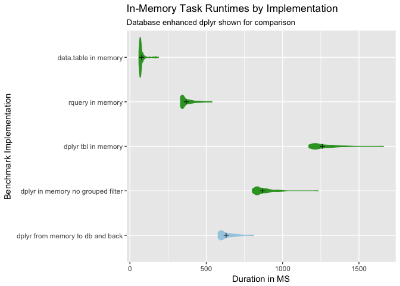

> (Figure from: [here](http://www.win-vector.com/blog/2018/01/rquery-fast-data-manipulation-in-r/).)

In addition `rquery` includes automatic column narrowing: where only columns used to construct the final result are pulled from initial tables. This feature is important in production (where data marts can be quite wide) and has show significant additional performance advantages

From a coding point of view the automatic narrowing effect looks like this.

```r
wp <- mk_td(table = 'd6',
                   columns = letters[1:5]) %.>%
  extend(., res := a + b)

# full query
cat(to_sql(wp, db))
```

```
## SELECT
##  `a`,
##  `b`,
##  `c`,
##  `d`,
##  `e`,
##  `a` + `b`  AS `res`
## FROM (
##  SELECT
##   `a`,
##   `b`,
##   `c`,
##   `d`,
##   `e`
##  FROM
##   `d6`
##  ) tsql_55352380060428343442_0000000000
```

```r
# longer pipeline
wn <- wp %.>%
  select_columns(., "res")

# notice select at end of the pipeline automatically
# gets propagated back to the beginning of the
# pipeline
cat(to_sql(wn, db))
```

```
## SELECT
##  `res`
## FROM (
##  SELECT
##   `a` + `b`  AS `res`
##  FROM (
##   SELECT
##    `a`,
##    `b`
##   FROM
##    `d6`
##   ) tsql_68681226693503471600_0000000000
## ) tsql_68681226693503471600_0000000001
```

A graph of the the effects of this kind of narrowing (for `dplyr` by hand as `dplyr` currently does not have the above type of automatic query analysis/optimization) shows the sensitivity to this optimization.

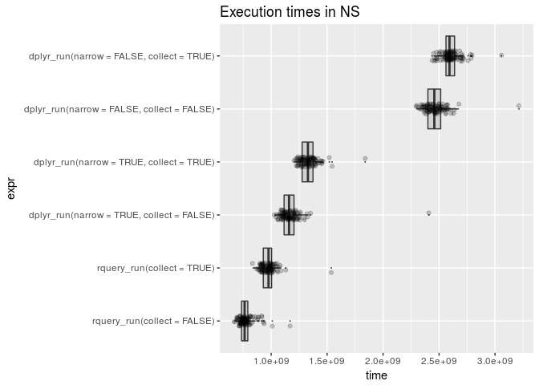

> (Figure from: [here](https://github.com/WinVector/rquery/blob/master/extras/PerfTest.md), please see also [here](http://www.win-vector.com/blog/2017/12/how-to-greatly-speed-up-your-spark-queries/).)

# Conclusion

`rquery` is new package, but it is already proving to be correct (avoiding [known data processing issues](http://www.win-vector.com/blog/2018/01/advisory-on-multiple-assignment-dplyrmutate-on-databases/)) and [performant](http://www.win-vector.com/blog/2018/01/advisory-on-multiple-assignment-dplyrmutate-on-databases/). For working with `R` at a big data scale (say using `PostgreSQL` or `Spark`) `rquery` is the right specialized tool for specifying data manipulation.

# See also

For deeper dives into specific topics, please see also:

- [`rquery README`](https://winvector.github.io/rquery/index.html)
- [Join Controller](https://github.com/WinVector/rquery/blob/master/extras/JoinController.md)
- [Join Dependency Sorting](https://github.com/WinVector/rquery/blob/master/extras/DependencySorting.md)
- [PerfTest](https://github.com/WinVector/rquery/blob/master/extras/PerfTest.md)
- [Assignment Partitioner](https://github.com/WinVector/rquery/blob/master/extras/AssigmentPartitioner.md)
- [DifferentDBs](https://github.com/WinVector/rquery/blob/master/extras/ExtraDBs.md)
- [`data.table based` implementation](https://github.com/WinVector/rqdatatable)

# Appendix: Always clean up on the way out

```r
options(old_o)
DBI::dbDisconnect(db)
```